# Explanation of the variations of the Borrower APR

## by Nour El Hedi Zrelli

## Investigation Overview

In this investigation, I am looking at the Borrower APR distribution and the main features affecting its variation which are the loan original amount and the employment status.

## Dataset Overview

The original dataset contains informations about 113937 loans with 81 variables on each loan such as loan amount, borrower rate ( interest rate ), current loan status, borrower income, and many others. In this ivestigation, I will be working with just the following variables : the Borrower APR, the loan original amount and the employment status. I will also remove 327 rows corresponding to 327 people having a stated monthly income over 30k which I considered as outliers.

## The distribution of the Borrower APR

The distribution of the borrower APR looks multimodal.There are many peaks on different intervals. There are few loans with close to 0 APR and few loans with APR over than 0.4.

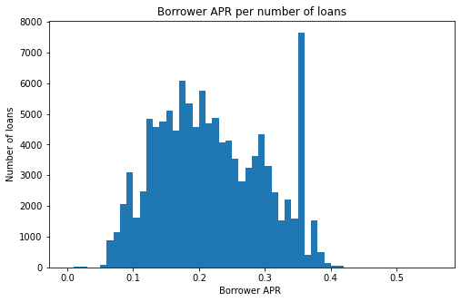

## The loan original amount distribution

There are important peaks around the 5k, 10k, 15k,20k,25k.

Loans are mostly multiples of 1k.

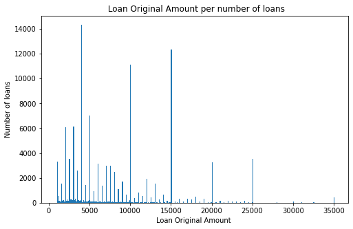

## The Borrower APR and the loan original amount

Looking at this bivariate relationship between the loan original amount and the BorrowerAPR, the loans with an amount less than 25k seem to have a borrower APR between 0.08 and 0.4, for loans with an amount over 25k the APR is between 0.1 and 0.2.

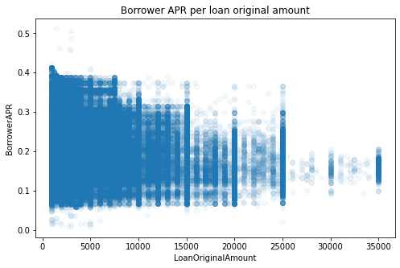

## The Borrower APR and the employment statuts

The boxplots show that for the non emlpoyed people, the APR is high : 75% of unemployed people gets an APR over 0.2.

For the employed and retired people, the APR seems balanced : 50% of people gets an APR over 0.2.

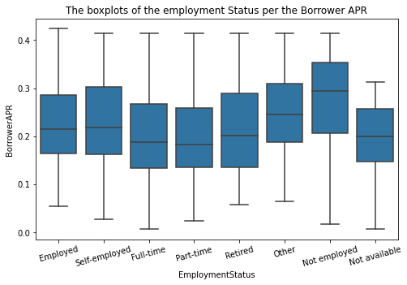